# Optional Section: More on Factors

Ted Laderas

6/1/2017

## More on manipulating factors

The following section is optional. Intermediate users may find these helpful. You should probably go on to Part 3 and learn some `dplyr` basics before starting with these, since we use `mutate()`, and it’s important to understand what it’s doing.

You’ll need to load the `forcats` package to use these. It’s included with the `tidyverse`, but is not loaded by default.

```r
library(tidyverse)
library(forcats)
#load the pets data again
load("data/pets.rda")
```

## Let’s build a bar plot of weights

To start out, let’s plot the weight for each pet as a bar graph.

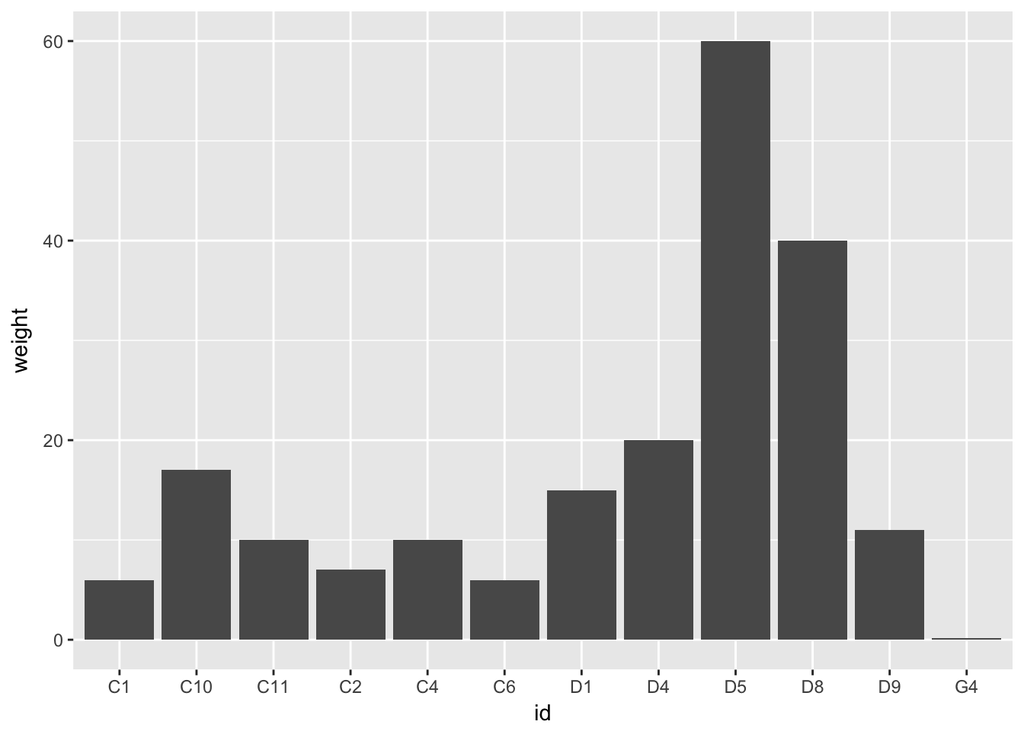

```r
ggplot(data=pets, aes(x=id,y=weight)) + geom_bar(stat="identity")
```

## Sort by another variable (intermediate)

Based on this visualization, what can we conclude about the weights of each type of animal? Which kind of animal weighs the most?

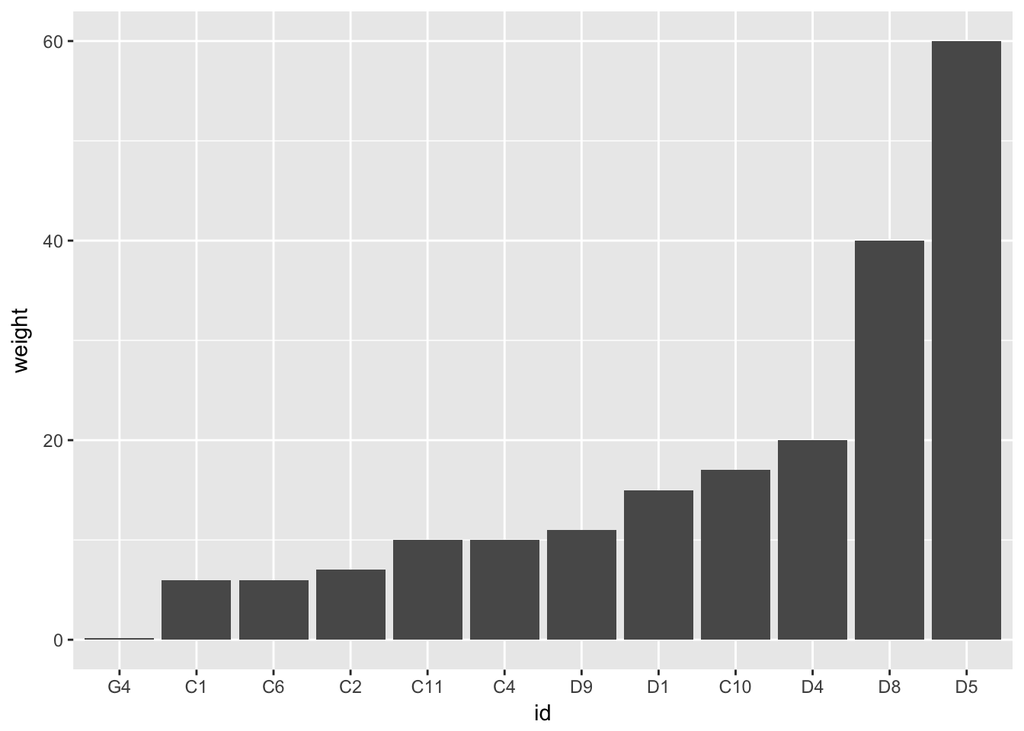

```r
pets %>% mutate(id=fct_reorder(id, weight)) %>%
  ggplot(aes(x=id,y=weight)) +
  geom_bar(stat="identity")
```

## Plot in Reverse Alphabetical Order

Often, you want to plot things in reverse alphametical order. This is useful because heatmaps and such are often plotted from the bottom.

You can use `fct_rev` to do this.

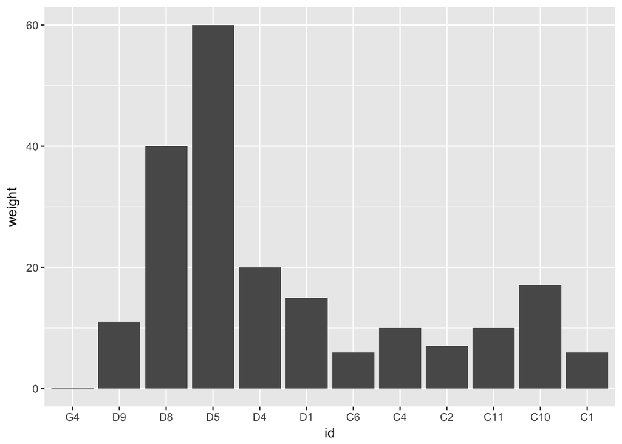

```r
library(forcats)
pets %>% mutate(id=fct_rev(id)) %>%
  ggplot(aes(x=id,y=weight)) +
  geom_bar(stat="identity")
```

## Sort by frequency

Going back to our `pets` data, sometimes we want to sort our count data by frequency. We can use `fct_infreq()` to do that.

How would we plot these in ascending order?

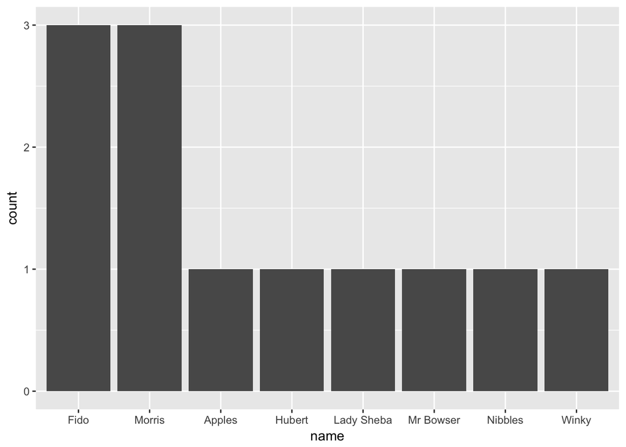

```r
pets %>% mutate(name = fct_infreq(name)) %>%
  ggplot(aes(x=name)) + geom_bar()
```

## Recode levels of a factor

Sometimes we want to rename the levels of a factor. Often the data may have obscure categories (such as abbreviations), and we want to be clear in our visualization.

As a silly example, let’s change the names of the levels to the latin genus names for each animal. Note we didn’t change the name of `gerbil`. What is the result?

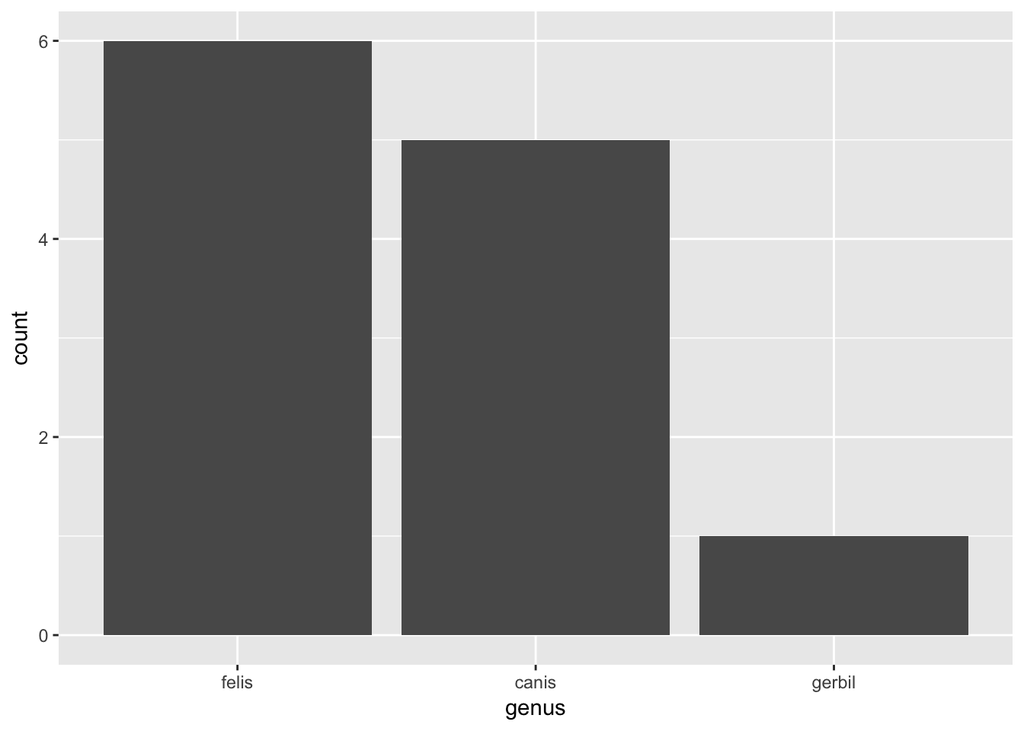

```r
pets %>% mutate(genus = fct_recode(animal,canis="dog", felis="cat")) %>%
  ggplot(aes(x=genus)) + geom_bar()
```

## Group levels of a factor together

Sometimes, your categories are too granular. It might make sense to aggregate some categories together. You can use `fct_collapse()` to do this.

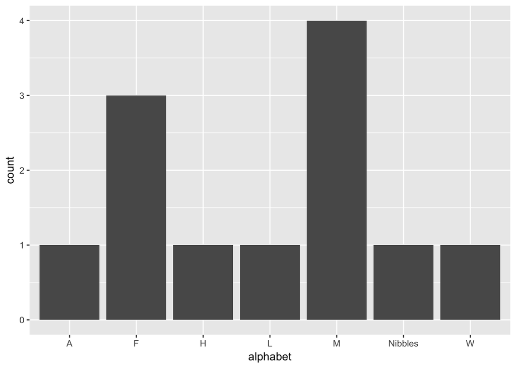

```r
pets %>% mutate(alphabet = fct_collapse(name,
                                        A=c("Apples"),
                                        F=c("Fido"),
                                        M=c("Morris", "Mr Bowser"),
                                        L=c("Lady Sheba"),
                                        H=c("Hubert"),
                                        W=c("Winky"))
                ) %>%
  ggplot(aes(x=alphabet)) + geom_bar()
```

## Intermediate Challenge

Recode the pets